# Linear Regression

Part 2a: one feature, the cost function and gradient descent. Part 2b: many features, vectorisation, feature scaling and evaluation

Khiem Nguyen

khiem.nguyen@glasgow.ac.uk

University of Glasgow

March 2026

## This lecture

Linear regression is the first model of the course, and many of its ideas return in every later lecture: a cost function, gradient descent, vectorised code, feature scaling and honest evaluation.

**Part 2a: one feature**

- the model $f_{w,b}(x) = wx + b$ and the meaning of $w$ and $b$;
- the **squared-error cost** $J(w,b)$, and why it is a good choice;
- minimising $J$: stationary points, and why we usually do not solve $\nabla J = \mathbf 0$;
- **gradient descent** and the **learning rate** $\alpha$.

**Part 2b: many features**

- the model $f_{\mathbf w,b}(\mathbf x) = \mathbf w\cdot\mathbf x + b$ in vector form;
- **vectorised** code, gradient descent for $n$ features, the **normal equation**;
- **feature scaling** and learning curves;
- feature engineering, polynomial regression, evaluation with MSE and $R^2$, and **scikit-learn**.

# Part 2a: linear regression with one feature

The regression problem, the cost function, minimising the cost, gradient descent, the learning rate

# The regression problem

## A motivating example

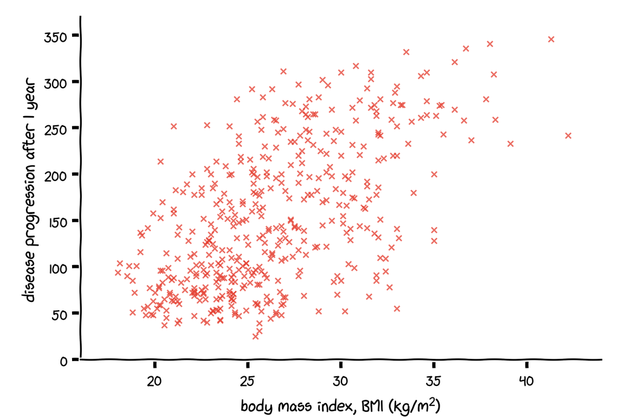

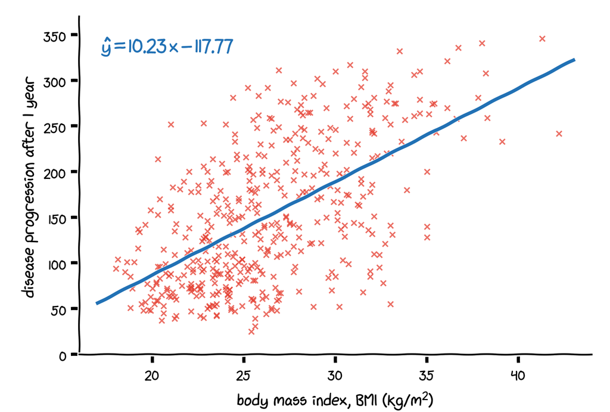

Each × is one of 442 diabetes patients:

- $x$: body mass index (BMI)
- $y$: a measure of disease progression one year later

Can we predict $y$ for a **new** patient from their BMI?

- **Supervised learning**: the training data contain the “right answers” $y$.
- **Regression**: the target $y$ is a *number*.
- **Classification**: the target is a *category* (e.g. diabetic or not), see Lecture 3.

Data: Efron, Hastie, Johnstone & Tibshirani (2004), *Annals of Statistics* 32(2); in Python `sklearn.datasets.load_diabetes`.

## Training data and notation

**Training set**

| $i$ | BMI $x^{(i)}$ | progression $y^{(i)}$ |
| --- | --- | --- |
| 1 | 32.1 | 151 |
| 2 | 21.6 | 75 |
| 3 | 30.5 | 141 |
| 4 | 25.3 | 206 |
| $\vdots$ | $\vdots$ | $\vdots$ |
| 442 | 19.6 | 57 |

**Notation**

- $x$: **input** variable, or **feature**
- $y$: **output** variable, or **target**
- $m$: number of training examples (here $m = 442$)
- $(x^{(i)}, y^{(i)})$: the $i$-th training example, $i = 1, \dots, m$

For example $\big(x^{(1)}, y^{(1)}\big) = (32.1,\ 151)$ and $x^{(2)} = 21.6$.

**Index, not exponent**

$x^{(2)}$ is the **second** example, $x^{(2)} = 21.6$. In contrast, $x^2 = x \cdot x$.

## From data to a model

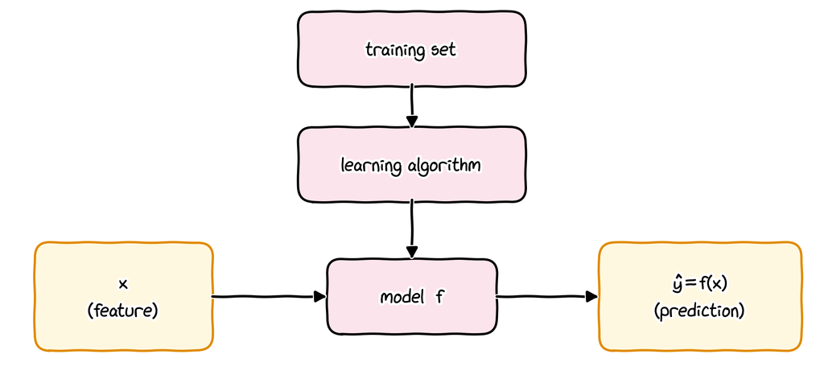

- A **learning algorithm** uses the training set to choose a function $f$, the **model** (also called the *hypothesis*).
- For a new input $x$, the model returns a **prediction** $\hat y = f(x)$, an estimate of the unknown true $y$.

| feature $x$ | $\longrightarrow$ | target $y$ |
| --- | --- | --- |
| size of a house | $f$ | price of the house |
| body mass index | $f$ | disease progression |

## Univariate linear regression

The simplest model is a straight line:

$$f_{w,b}(x) = w\,x + b, \qquad w, b \in \mathbb{R}$$

- $w$ and $b$ are the **parameters** of the model, also called **weight** and **bias**.
- The subscript in $f_{w,b}$ reminds us that the line depends on the choice of $w$ and $b$.
- One input feature: **univariate** linear regression, or linear regression with one variable.
- Several features (part 2b): **multiple** linear regression.

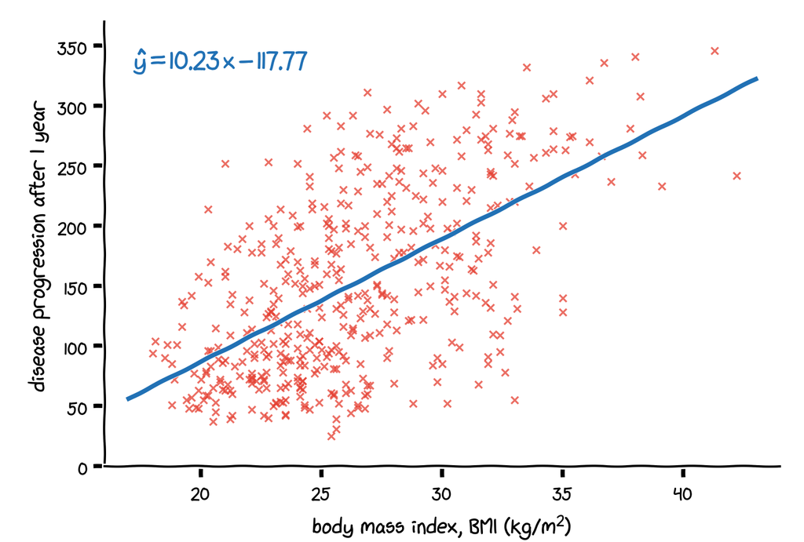

## What do $w$ and $b$ mean?

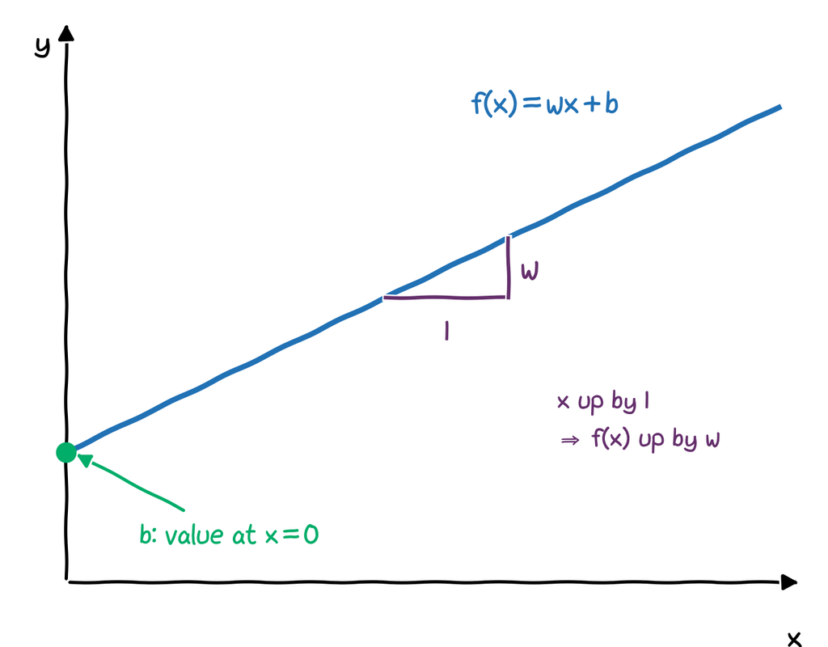

- $w$ is the **slope**: the change in the prediction when $x$ increases by one unit.
- $b$ is the **intercept**: the prediction at $x = 0$.

For the diabetes data, the best line (we will see how to find it) is
$$\hat y = 10.23\,x - 117.77 .$$

- Each extra unit of BMI goes with about 10 points more disease progression, on average.
- The intercept $-117.77$ is the prediction for BMI $= 0$. It has no physical meaning: no patient has BMI $0$, and progression cannot be negative. **Do not extrapolate far outside the data.**

## Fantastic parameters and where to find them

| $x$ | $y$ |
| --- | --- |
| 32.1 | 151 |
| 21.6 | 75 |
| 30.5 | 141 |
| $\vdots$ | $\vdots$ |

**Model**

$f_{w,b}(x) = {\color{red}{w}}\,x + {\color{red}{b}}$, with parameters ${\color{red}{w}}, {\color{red}{b}}$

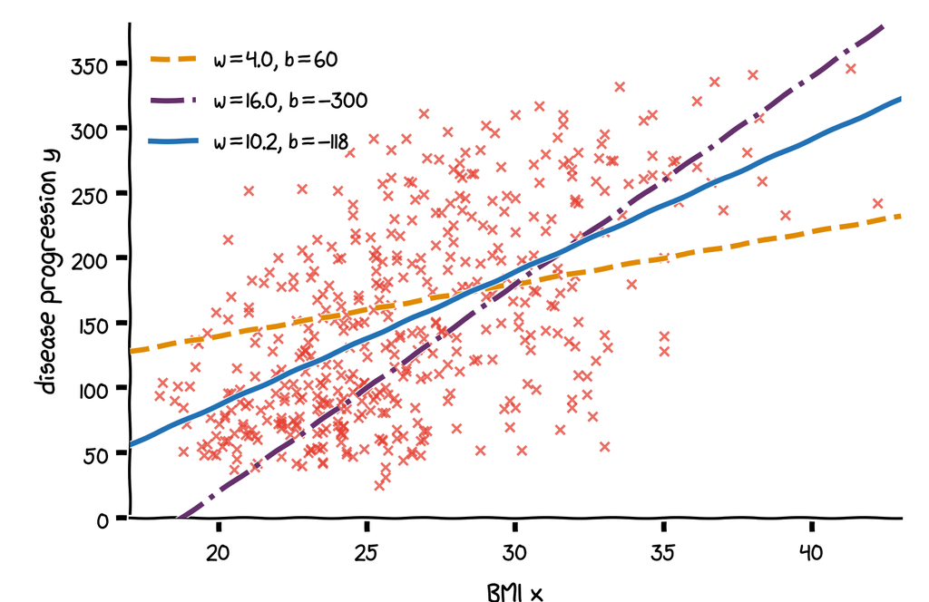

Which values of $w$ and $b$ give a **good** line, and how do we **find** them?

1. Measure how well a line fits the data: the **cost function**.
2. Find the parameters with the smallest cost: **optimisation**.

# The cost function

## How well does a line fit?

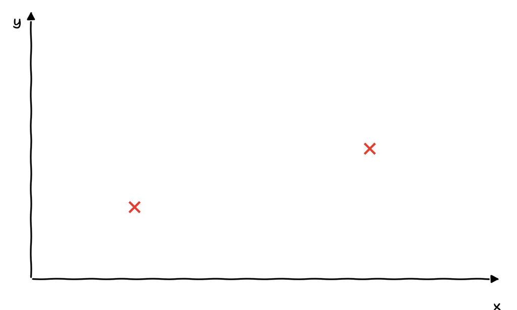

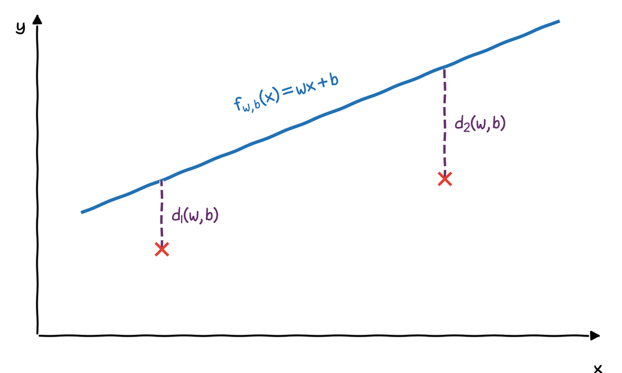

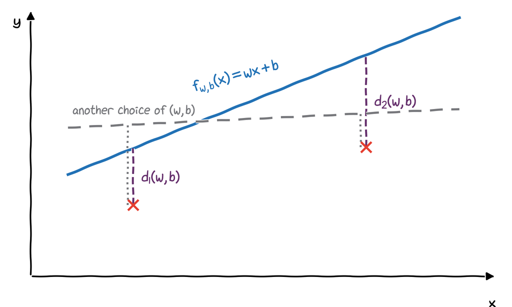

For a candidate line, the **vertical distance** between data point $i$ and the line is
$$d_i(w,b) = \big|f_{w,b}(x^{(i)}) - y^{(i)}\big| .$$

- A different choice of $(w,b)$ gives different distances.
- A good fit has small distances:
  $$\min_{w,b}\ \big[d_1(w,b) + d_2(w,b)\big]$$
- We use *vertical* distances because the error we care about is the error in the prediction of $y$.

## Many data points

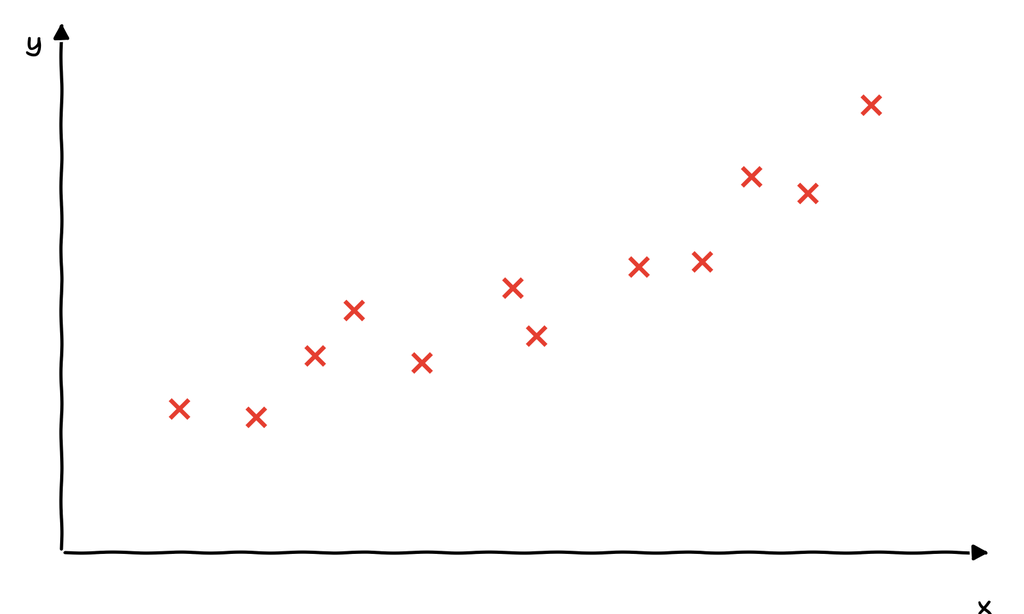

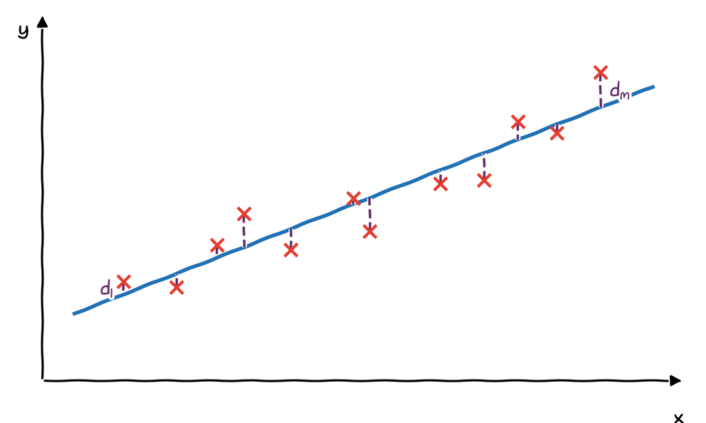

With $m$ data points there are $m$ distances $d_1, \dots, d_m$. Minimise their **average**:
$$\min_{w,b}\ \frac{1}{m}\sum_{i=1}^{m} d_i(w,b)$$

- Dividing by $m$ does not change the best $(w,b)$.
- But the cost no longer grows with the size of the data set, so costs on data sets of different sizes can be compared.

## Absolute or squared distances?

Three points $(1,3)$, $(2,4)$, $(3,5)$, which lie exactly on the line $y = x + 2$:

$$\begin{aligned}
G(w,b) &= \tfrac{1}{3}\Big(|w + b - 3| + |2w + b - 4| + |3w + b - 5|\Big) && \text{(absolute)}\\
Q(w,b) &= \tfrac{1}{3}\Big((w + b - 3)^2 + (2w + b - 4)^2 + (3w + b - 5)^2\Big) && \text{(squared)}
\end{aligned}$$

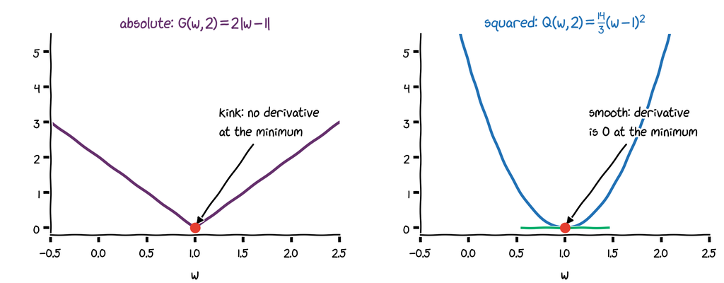

- $G$ is **piecewise linear**, with kinks where it is not differentiable, including at the minimum. Minimising it means checking one region after another.
- $Q$ is a smooth **quadratic**: differentiable everywhere, with derivative $0$ at the minimum.

## The squared-error cost function

For example $i$ the model predicts $\hat y^{(i)} = f_{w,b}(x^{(i)}) = w\,x^{(i)} + b$. The **cost function** is

$$J(w,b) = \frac{1}{2m}\sum_{i=1}^{m}\big(\hat y^{(i)} - y^{(i)}\big)^2
= \frac{1}{2m}\sum_{i=1}^{m}\big(w\,x^{(i)} + b - y^{(i)}\big)^2 .$$

- $\big(\hat y^{(i)} - y^{(i)}\big)^2$ is the **squared error** of example $i$; squaring also penalises large errors more than small ones.
- $\frac{1}{m}\sum_{i}$ averages over all examples: the **mean squared error** (MSE).
- The extra factor $\frac12$ is for convenience only: it cancels the $2$ that appears when we differentiate the square. Multiplying $J$ by a positive constant does not move its minimum.

**Goal**

Find $w, b$ such that $\hat y^{(i)}$ is close to $y^{(i)}$ for all training examples: $\quad\displaystyle \min_{w,b}\ J(w,b)$.

## Building intuition: fix $b = 0$

**General case**

- Model: $f_{w,b}(x) = wx + b$
- Parameters: $w$, $b$
- Cost:
  $$J(w,b) = \frac{1}{2m}\sum_{i=1}^{m}\big(f_{w,b}(x^{(i)}) - y^{(i)}\big)^2$$
- Goal: $\displaystyle\min_{w,b} J(w,b)$

**Simplified case, $b = 0$**

- Model: $f_w(x) = wx$ (lines through the origin)
- Parameter: $w$
- Cost:
  $$J(w) = \frac{1}{2m}\sum_{i=1}^{m}\big(w\,x^{(i)} - y^{(i)}\big)^2$$
- Goal: $\displaystyle\min_{w} J(w)$

Toy data set with $m = 3$: $\ (x^{(i)}, y^{(i)}) = (1, 1),\ (2, 2),\ (3, 3)$.

## $J(w)$ for the toy data, one $w$ at a time

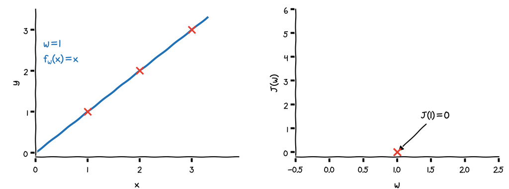

$$w = 1:\quad J(1) = \frac{1}{2\cdot 3}\big[(1-1)^2 + (2-2)^2 + (3-3)^2\big] = 0$$

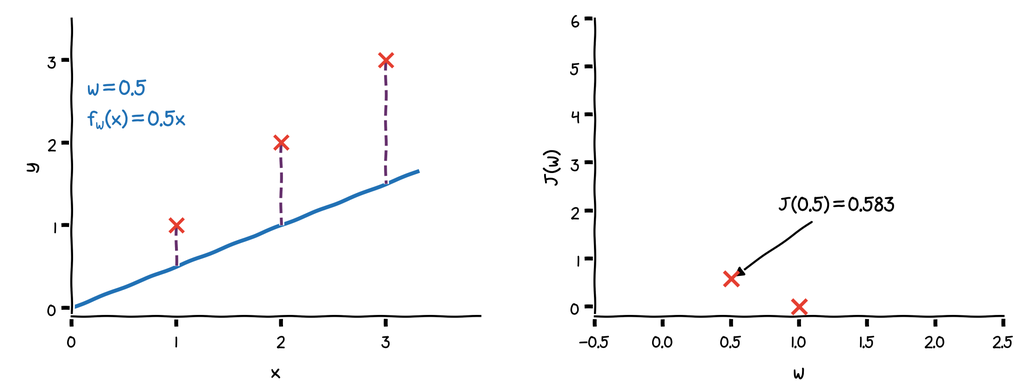

$$w = 0.5:\quad J(0.5) = \frac{1}{6}\big[(0.5-1)^2 + (1-2)^2 + (1.5-3)^2\big] = \frac{3.5}{6} = \frac{7}{12} \approx 0.583$$

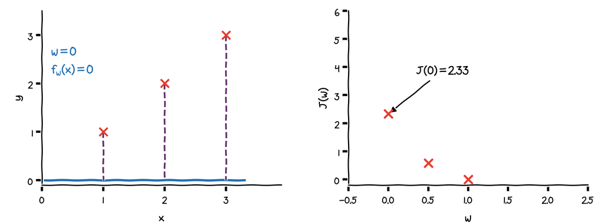

$$w = 0:\quad J(0) = \frac{1}{6}\big[(0-1)^2 + (0-2)^2 + (0-3)^2\big] = \frac{14}{6} = \frac{7}{3} \approx 2.333$$

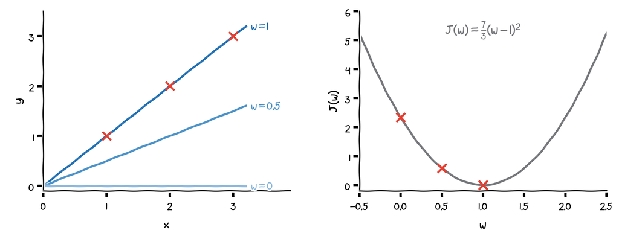

$$\text{any } w:\quad J(w) = \frac{1}{6}\big[(w-1)^2 + (2w-2)^2 + (3w-3)^2\big] = \frac{1+4+9}{6}(w-1)^2 = \frac{7}{3}(w-1)^2$$

## Surface plots and contour plots

$f(x_1, x_2) = x_1^2 + x_2^2$

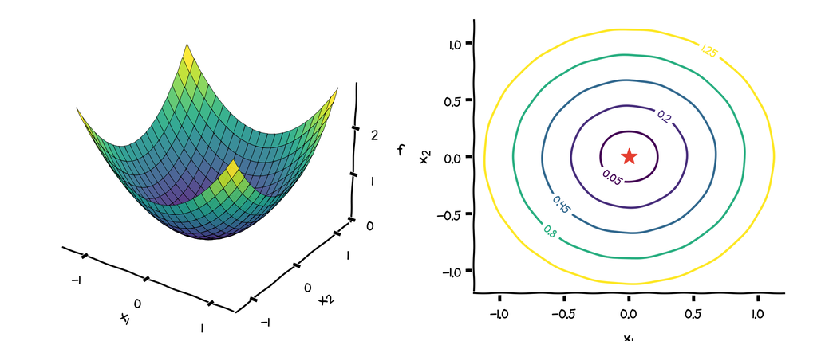

- Left: the graph of $f$ is a **bowl**. Right: **contour lines** (level curves) join the points where $f$ has the same value, like height lines on a hiking map.

## The full cost $J(w,b)$ for the toy data

$$J(w,b) = \frac{1}{6}\Big[(w + b - 1)^2 + (2w + b - 2)^2 + (3w + b - 3)^2\Big]
= \frac{7}{3}(w-1)^2 + 2\,(w-1)\,b + \frac{1}{2}\,b^2$$

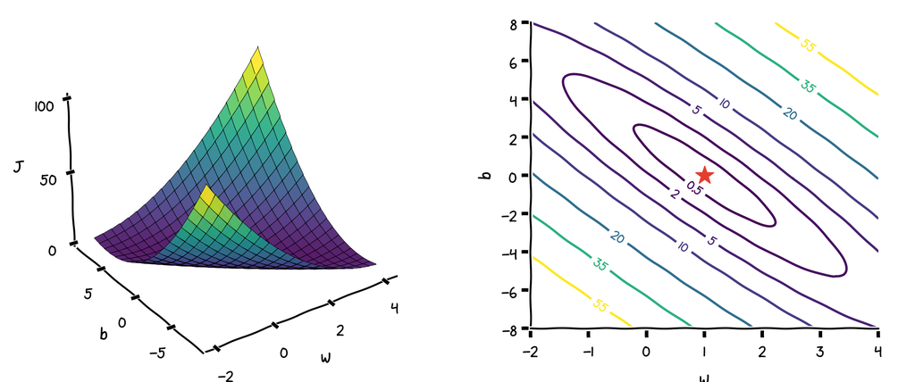

- Again a bowl, with its minimum $J = 0$ at $(w, b) = (1, 0)$, i.e. the line $\hat y = x$.
- The contour ellipses are tilted because of the mixed term $2(w-1)b$: $w$ and $b$ are coupled.

## $J(w,b)$ is always a quadratic bowl

Expanding the square for **any** data set gives

$$J(w,b) = \frac{1}{2m}\sum_{i=1}^{m}\big(x^{(i)}w + b - y^{(i)}\big)^2
= \frac12\,\overline{x^2}\,w^2 + \bar x\,wb + \frac12\,b^2 - \overline{xy}\,w - \bar y\,b + \frac12\,\overline{y^2},$$

where a bar denotes an average over the training set, e.g. $\bar x = \frac1m\sum_i x^{(i)}$, $\ \overline{xy} = \frac1m\sum_i x^{(i)}y^{(i)}$.

- However complicated the data are, $J$ contains only the terms $w^2$, $wb$, $b^2$, $w$, $b$ and a constant: it is a **quadratic function** of $(w,b)$.
- It is a **convex bowl** with exactly one minimum, as long as the $x^{(i)}$ are not all equal.<sup>1</sup>
- Check: for the toy data $\overline{x^2} = \overline{xy} = \overline{y^2} = \frac{14}{3}$ and $\bar x = \bar y = 2$, which reproduces the previous slide.
[^1]: The quadratic part is $\frac12\big(\overline{x^2}\,w^2 + 2\bar x\,wb + b^2\big) = \frac12\big(\overline{(xw + b)^2}\big) \ge 0$, and it is zero only if $x^{(i)}w + b = 0$ for all $i$, which forces $w = b = 0$ unless all $x^{(i)}$ are equal.

# Minimising the cost

## Stationary points

To minimise a differentiable function $f(x_1, \dots, x_n)$, look for points where the **gradient** vanishes:

$$\nabla f(\mathbf x) = \mathbf 0
\quad\Longleftrightarrow\quad
\frac{\partial f}{\partial x_1}(\mathbf x) = 0,\ \ \dots,\ \ \frac{\partial f}{\partial x_n}(\mathbf x) = 0 .$$

A solution $\mathbf x^* = (x_1^*, \dots, x_n^*)$ is called a **stationary point**.

- At a minimum the gradient is zero: $\nabla f = \mathbf 0$ is **necessary**.
- It is **not sufficient**: a stationary point can also be a maximum or a saddle point.
- For a **convex** function, such as our bowl-shaped $J$, every stationary point is a global minimum.

## Stationary points: 1D example

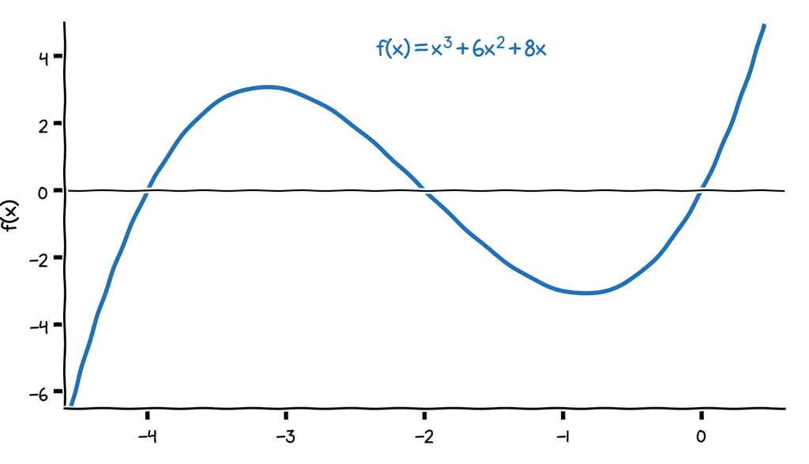

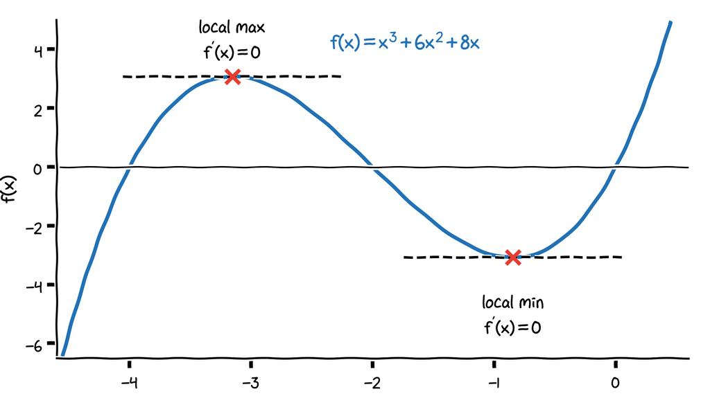

$$f(x) = x^3 + 6x^2 + 8x$$

$$f'(x) = 3x^2 + 12x + 8 = 0$$
$$\Rightarrow\ x = -2 \pm \tfrac{2}{\sqrt 3}$$

- $x_{\max} \approx -3.15$ is a **local maximum**, $x_{\min} \approx -0.85$ a **local minimum**.
- Both are only *local*: $f(x) \to -\infty$ as $x \to -\infty$, so $f$ has no global minimum.

## Stationary points: 2D example

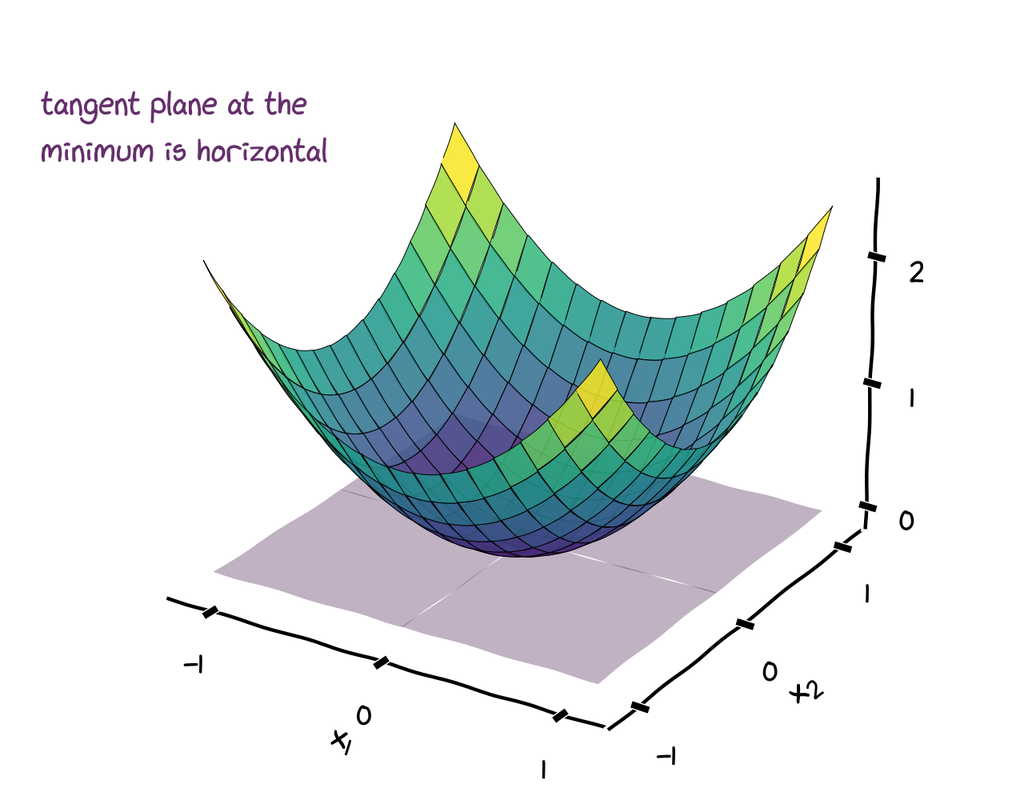

$$f(x_1, x_2) = x_1^2 + x_2^2$$

$$\nabla f(x_1, x_2) = \begin{pmatrix} 2x_1 \\ 2x_2 \end{pmatrix} = \mathbf 0
\ \Rightarrow\ (x_1^*, x_2^*) = (0, 0)$$

At the minimum the tangent plane to the surface is horizontal: the surface is “flat” in every direction.

## Back to the toy example

$$J(w,b) = \frac{7}{3}(w-1)^2 + 2(w-1)b + \frac{1}{2}b^2$$

$$\left\{\begin{aligned}
\frac{\partial J}{\partial w} &= \frac{14}{3}(w-1) + 2b = 0\\[2pt]
\frac{\partial J}{\partial b} &= 2(w-1) + b = 0
\end{aligned}\right.
\quad\Longrightarrow\quad
\left\{\begin{aligned} w &= 1\\ b &= 0 \end{aligned}\right.$$

(From the second equation $b = -2(w-1)$; substituting gives $\frac23(w-1) = 0$.)

The fitted line is $\hat y = x$, which passes through all three data points, so $J(1, 0) = 0$.

## A closed-form solution, so why gradient descent?

For univariate linear regression, $\nabla J = \mathbf 0$ can be solved by hand:

$$w^* = \frac{\overline{xy} - \bar x\,\bar y}{\overline{x^2} - \bar x^2},
\qquad
b^* = \bar y - w^*\,\bar x .$$

For the diabetes data this gives $w^* = 10.23$ and $b^* = -117.77$.

However:

- With many features we must solve a linear system (the **normal equation**, part 2b), which becomes expensive when there are many features.
- For almost every other model (logistic regression, neural networks), $\nabla J = \mathbf 0$ has **no closed-form solution** at all.

We need a general, **iterative** method that only uses the gradient: **gradient descent**.

# Gradient descent

## The idea

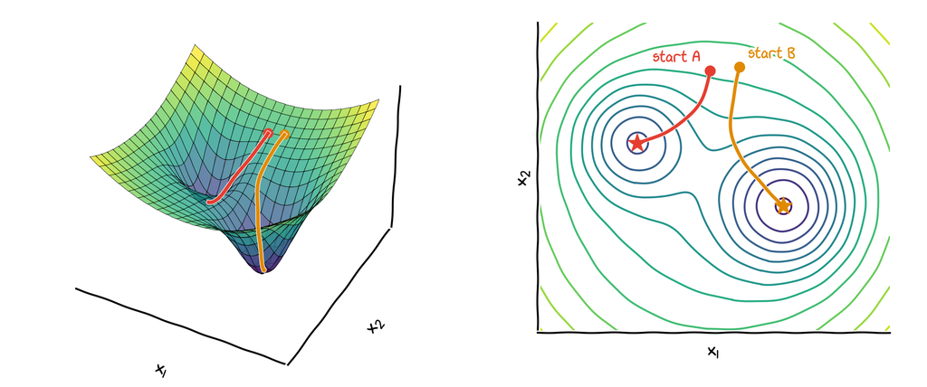

**Problem**: minimise $f(\mathbf x) = f(x_1, \dots, x_n)$.

**Idea**

1. Start from an initial guess $\mathbf x^{[0]}$.
2. Take a small step **downhill**, so that $f$ decreases.
3. Repeat until we (almost) stop moving: we are at or near a minimum.

Different starting points can end in different **local** minima. This cannot happen for linear regression: $J$ is a bowl with a single minimum.

## Which way is downhill?

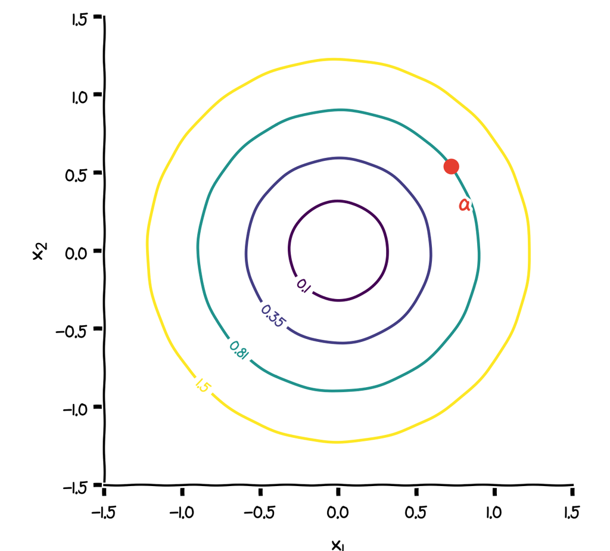

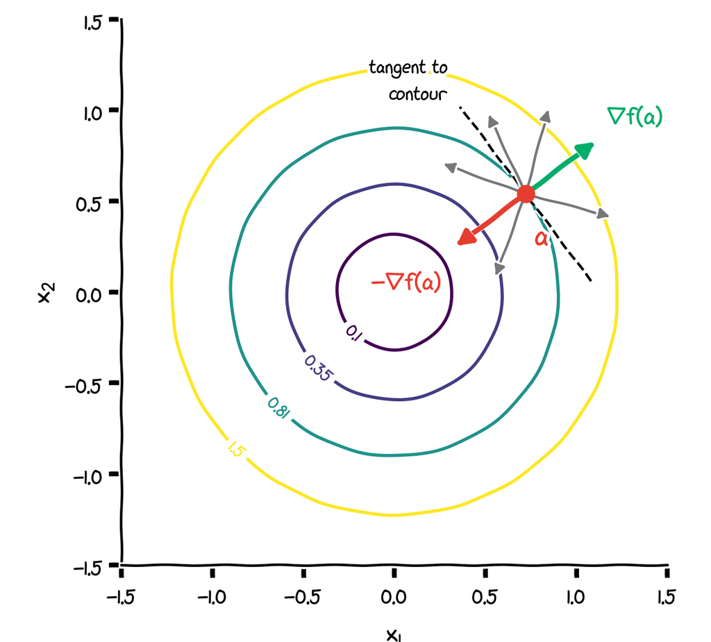

Standing at a point $\mathbf a$, in which unit direction $\mathbf n$ ($\|\mathbf n\| = 1$) does $f$ change fastest?

The rate of change of $f$ in direction $\mathbf n$ is the **directional derivative**
$$D_{\mathbf n} f(\mathbf a) = \nabla f(\mathbf a)\cdot\mathbf n = \|\nabla f(\mathbf a)\|\cos\theta ,$$
where $\theta$ is the angle between $\mathbf n$ and $\nabla f(\mathbf a)$.

- Largest for $\theta = 0$: $f$ **increases** fastest along $\nabla f(\mathbf a)$.
- Most negative for $\theta = \pi$: $f$ **decreases** fastest along $-\nabla f(\mathbf a)$.
- Zero for $\theta = \pi/2$: along the contour line, so $\nabla f(\mathbf a)$ is perpendicular to the contour through $\mathbf a$.

## The gradient descent algorithm

Start from $\mathbf x^{[0]}$ and repeat until convergence:

$$\mathbf x^{[t+1]} = \mathbf x^{[t]} - {\color{red}{\alpha}}\,{\color{blue}{\nabla f\big(\mathbf x^{[t]}\big)}},
\qquad t = 0, 1, 2, \dots$$

or, component by component,

$$x_j^{[t+1]} = x_j^{[t]} - {\color{red}{\alpha}}\,{\color{blue}{\frac{\partial f}{\partial x_j}\big(\mathbf x^{[t]}\big)}},
\qquad j = 1, \dots, n .$$

- ${\color{red}{\alpha > 0}}$ is the **learning rate** (step size). It is usually kept fixed, but may also change with $t$ (a *learning-rate schedule* $\alpha^{[t]}$).
- ${\color{blue}{\partial f/\partial x_j}}$ are the partial derivatives, i.e. the components of the gradient.
- “Until convergence” in practice: stop when $\|\nabla f(\mathbf x^{[t]})\|$ is tiny, when $f$ hardly decreases any more, or after a maximum number of iterations.

## Why the minus sign?

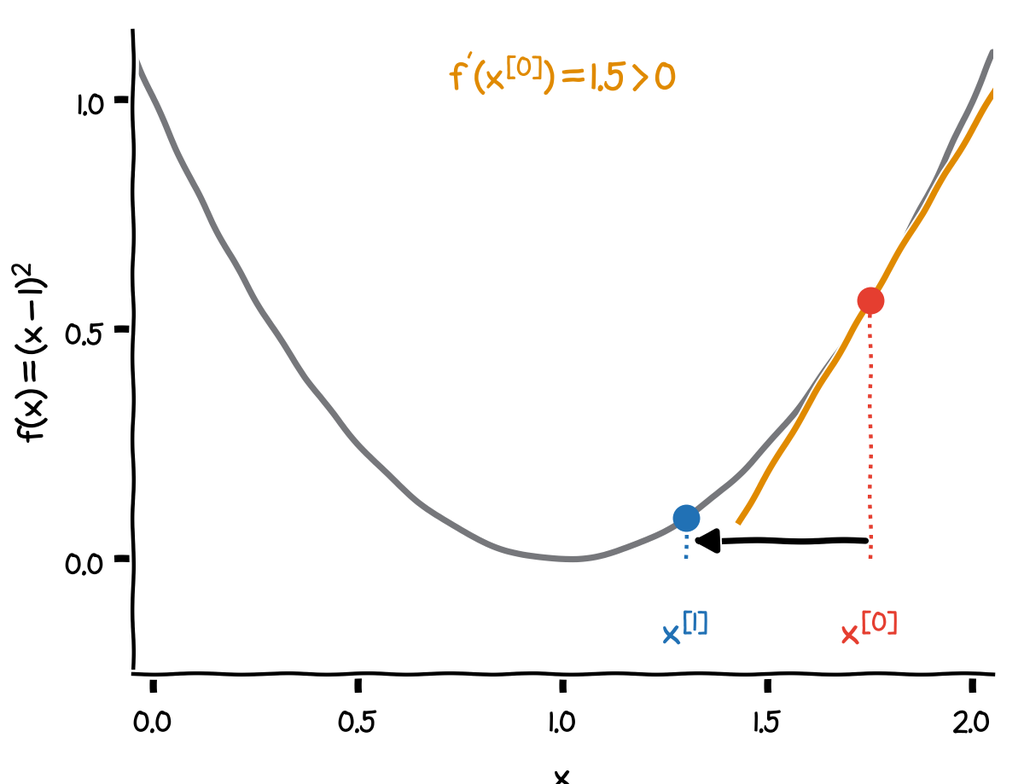

If $f'(x^{[0]}) > 0$, $f$ increases to the right, so we move **left**:
$$x^{[1]} = x^{[0]} - \underbrace{\alpha}_{>0}\,\underbrace{f'(x^{[0]})}_{>0} < x^{[0]}$$

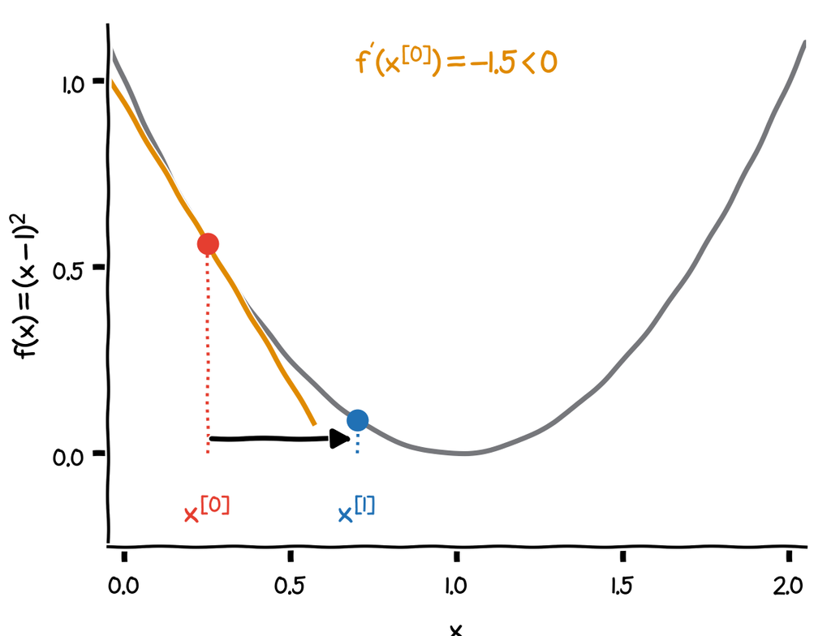

If $f'(x^{[0]}) < 0$, $f$ decreases to the right, so we move **right**:
$$x^{[1]} = x^{[0]} - \underbrace{\alpha}_{>0}\,\underbrace{f'(x^{[0]})}_{<0} > x^{[0]}$$

In both cases we move **downhill**. With a plus sign we would climb uphill instead: that is **gradient ascent**, used for *maximisation* problems.

## Update all variables simultaneously

**Correct**: all partial derivatives are evaluated at the *old* point $\mathbf x^{[t]}$

$$\begin{aligned}
x_1^{[t+1]} &= x_1^{[t]} - \alpha\,\tfrac{\partial f}{\partial x_1}\big(x_1^{[t]}, x_2^{[t]}\big)\\
x_2^{[t+1]} &= x_2^{[t]} - \alpha\,\tfrac{\partial f}{\partial x_2}\big(x_1^{[t]}, x_2^{[t]}\big)
\end{aligned}$$

```python
df_dx1 = compute_df_dx1(x1, x2)
df_dx2 = compute_df_dx2(x1, x2)
x1 = x1 - alpha * df_dx1
x2 = x2 - alpha * df_dx2
```

**Incorrect**: $x_1$ is updated before $\partial f/\partial x_2$ is computed

$$\begin{aligned}
x_1^{[t+1]} &= x_1^{[t]} - \alpha\,\tfrac{\partial f}{\partial x_1}\big(x_1^{[t]}, x_2^{[t]}\big)\\
x_2^{[t+1]} &= x_2^{[t]} - \alpha\,\tfrac{\partial f}{\partial x_2}\big({\color{red}{x_1^{[t+1]}}}, x_2^{[t]}\big)
\end{aligned}$$

```python
df_dx1 = compute_df_dx1(x1, x2)
x1 = x1 - alpha * df_dx1
df_dx2 = compute_df_dx2(x1, x2)  # uses NEW x1!
x2 = x2 - alpha * df_dx2
```

With NumPy arrays the update `x = x - alpha * grad_f(x)` is automatically simultaneous.

## Gradient of the squared-error cost

$$J(w,b) = \frac{1}{2m}\sum_{i=1}^{m}\big(f_{w,b}(x^{(i)}) - y^{(i)}\big)^2,
\qquad f_{w,b}(x) = wx + b$$

By the chain rule, with $\partial f_{w,b}/\partial w = x$ and $\partial f_{w,b}/\partial b = 1$:

$$\begin{aligned}
\frac{\partial J}{\partial w} &= \frac{1}{2m}\sum_{i=1}^{m} 2\big(f_{w,b}(x^{(i)}) - y^{(i)}\big)\,x^{(i)}
= \frac{1}{m}\sum_{i=1}^{m}\big(f_{w,b}(x^{(i)}) - y^{(i)}\big)\,x^{(i)}\\[4pt]
\frac{\partial J}{\partial b} &= \frac{1}{m}\sum_{i=1}^{m}\big(f_{w,b}(x^{(i)}) - y^{(i)}\big)
\end{aligned}$$

- The $\frac12$ in $J$ cancels the $2$ from differentiating the square.
- Each term is (prediction error) $\times$ (derivative of the model with respect to the parameter).
- Check with the toy data: $\frac{\partial J}{\partial w} = \frac{14}{3}(w-1) + 2b$ and $\frac{\partial J}{\partial b} = 2(w-1) + b$, as before.

## Batch gradient descent for linear regression

Repeat until convergence, updating $w$ and $b$ **simultaneously**:

$$\begin{aligned}
w &\leftarrow w - \alpha\,\frac{1}{m}\sum_{i=1}^{m}\big(w x^{(i)} + b - y^{(i)}\big)\,x^{(i)}\\
b &\leftarrow b - \alpha\,\frac{1}{m}\sum_{i=1}^{m}\big(w x^{(i)} + b - y^{(i)}\big)
\end{aligned}$$

On the toy data, $\alpha = 0.3$ and 150 iterations from $(w,b) = (-1.5, 6)$ give $(0.989, 0.024)$; the exact answer is $(1, 0)$.

```python
import numpy as np

def gradient_descent(x, y, w=0.0, b=0.0,
                     alpha=0.01, n_iters=1000):
    """Batch gradient descent for f(x) = w*x + b.
    x, y: 1D NumPy arrays of length m."""
    m = len(x)
    for _ in range(n_iters):
        err = w * x + b - y   # errors, shape (m,)
        dJ_dw = np.sum(err * x) / m
        dJ_db = np.sum(err) / m
        # simultaneous update
        w, b = w - alpha * dJ_dw, b - alpha * dJ_db
    return w, b
```

## Gradient descent in action

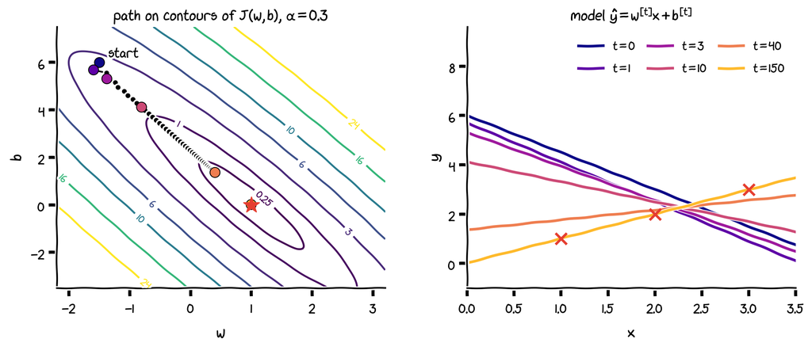

- Left: the path $(w^{[t]}, b^{[t]})$ on the contours of $J$. Each step is perpendicular to the contour it starts from; the path quickly reaches the long, narrow valley and then slowly moves along it to the minimum $\star$ at $(1, 0)$.
- Right: the corresponding lines $\hat y = w^{[t]}x + b^{[t]}$ approach the data.

# The learning rate

## Small learning rates: slow convergence

Test problem: $f(x) = (x-1)^2$, minimum at $x^* = 1$, start at $x^{[0]} = 0.1$, 15 iterations of $\ x^{[t+1]} = x^{[t]} - \alpha\, f'(x^{[t]}) = x^{[t]} - 2\alpha\,(x^{[t]} - 1)$.

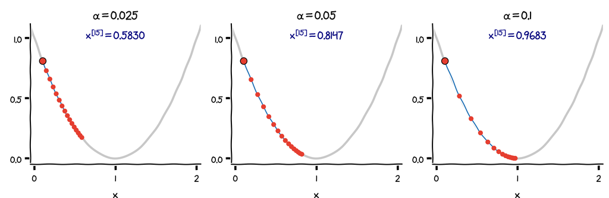

If $\alpha$ is **too small**, gradient descent takes tiny steps and converges **slowly**.

## Larger learning rates: overshooting

Same problem, larger $\alpha$:

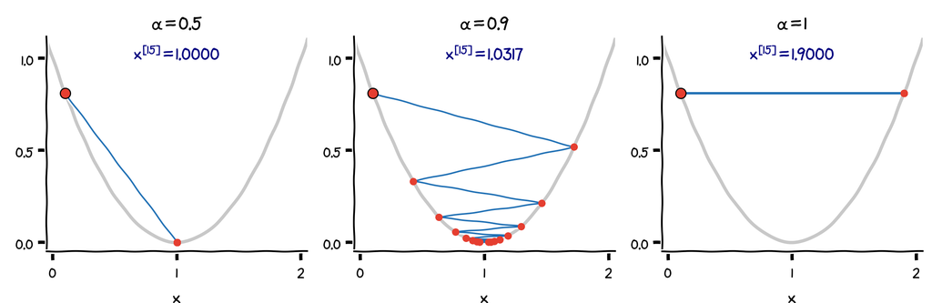

- $\alpha = 0.5$: the minimum is reached in a single step.
- $\alpha = 0.9$: each step **overshoots** the minimum; the iterates oscillate around $x^* = 1$ but still converge.
- $\alpha = 1$: the iterates bounce between $0.1$ and $1.9$ forever and **never converge**.

## Too large: divergence

Start very close to the minimum, $x^{[0]} = 0.95$, but use $\alpha = 1.1$:

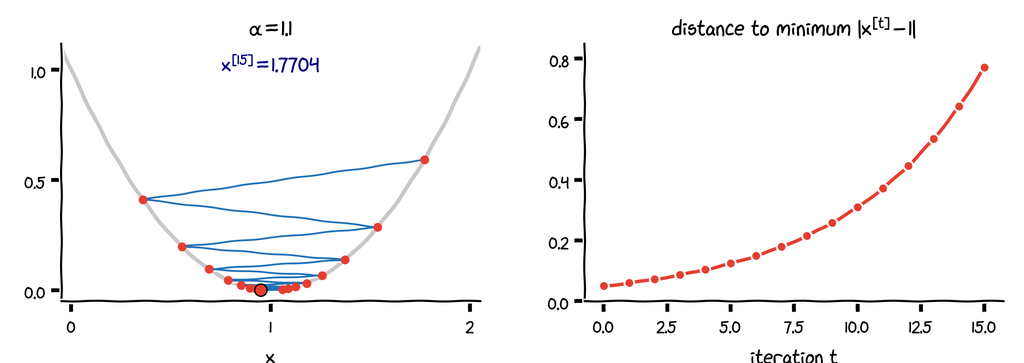

If $\alpha$ is **too large**, gradient descent may

- overshoot and never reach the minimum,
- oscillate without converging, or even
- **diverge**: here the distance to the minimum grows by a factor $1.2$ at every step.

## Why? An exact analysis

For $f(x) = (x-1)^2$ the update can be solved exactly:
$$x^{[t+1]} - 1 = (1 - 2\alpha)\big(x^{[t]} - 1\big)
\quad\Longrightarrow\quad
x^{[t]} - 1 = (1 - 2\alpha)^t\,\big(x^{[0]} - 1\big).$$

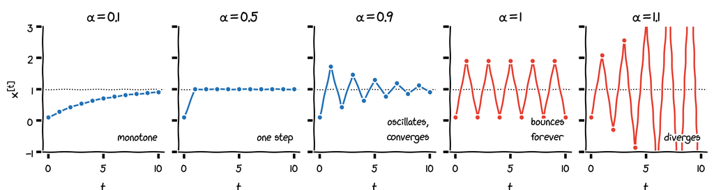

- Gradient descent converges if and only if $|1 - 2\alpha| < 1$, i.e. $0 < \alpha < 1$; for $\alpha < 0.5$ monotonically, for $0.5 < \alpha < 1$ with oscillations.
- More generally, for a quadratic with curvature $f'' = \kappa$ (here $\kappa = 2$), gradient descent converges if and only if $0 < \alpha < 2/\kappa$: **the steeper the bowl, the smaller $\alpha$ must be.**

## Batch, mini-batch and stochastic gradient descent

**Batch** gradient descent: every step uses **all** $m$ training examples,
$$\frac{\partial J}{\partial w} = \frac{1}{m}\sum_{i=1}^{m}\big(f_{w,b}(x^{(i)}) - y^{(i)}\big)\,x^{(i)} .$$

**Mini-batch** gradient descent: every step uses a random subset $B \subset \{1, \dots, m\}$ of the examples, with $|B| \ll m$ (e.g. 32 to 512), to **approximate** the gradient,
$$\frac{\partial J}{\partial w} \approx \frac{1}{|B|}\sum_{i \in B}\big(f_{w,b}(x^{(i)}) - y^{(i)}\big)\,x^{(i)} .$$

**Stochastic** gradient descent (SGD): $|B| = 1$, one example per step.

Smaller batches give cheaper but noisier steps. They are essential for very large data sets and for training neural networks later in the course.

## Summary of part 2a

- **Model**: $f_{w,b}(x) = wx + b$, with slope $w$ and intercept $b$.
- **Cost**: $J(w,b) = \frac{1}{2m}\sum_{i=1}^{m}\big(f_{w,b}(x^{(i)}) - y^{(i)}\big)^2$, a convex quadratic bowl.
- **Minimum**: where $\nabla J = \mathbf 0$. Linear regression has a closed-form solution, most models do not.
- **Gradient descent**: $\mathbf x \leftarrow \mathbf x - \alpha\,\nabla f(\mathbf x)$, updating all components simultaneously.
- **Gradient of the cost**: $\frac{\partial J}{\partial w} = \frac1m\sum_i\big(f_{w,b}(x^{(i)}) - y^{(i)}\big)x^{(i)}$, $\ \frac{\partial J}{\partial b} = \frac1m\sum_i\big(f_{w,b}(x^{(i)}) - y^{(i)}\big)$.
- **Learning rate**: too small gives slow convergence; too large gives oscillation or divergence.

**Next, part 2b**: several features, vectorisation, the normal equation, and feature scaling. (On the raw diabetes data, gradient descent needs about $100\,000$ iterations to converge; feature scaling fixes this.)

## Check your understanding: part 2a

1. Why is $J(w,b) \ge 0$ for every $(w,b)$? When is $J(w,b) = 0$?
2. During gradient descent, $J$ **increases** from one iteration to the next. What is the most likely cause, and what do you change?
3. For $f(x) = (x-1)^2$, for which learning rates does gradient descent converge?
4. Suppose we force $w = 0$. What does the model predict, and which $b$ minimises $J$?

# Part 2b: linear regression with many features

Multiple features, vectorisation, gradient descent for $n$ features, the normal equation, feature scaling, learning curves, feature engineering, evaluation, scikit-learn

## Where we are

In part 2a we built the whole machinery for **one** feature:

- model $f_{w,b}(x) = wx + b$, cost $J(w,b) = \frac{1}{2m}\sum_i\big(f_{w,b}(x^{(i)}) - y^{(i)}\big)^2$;
- gradient descent $w \leftarrow w - \alpha\,\partial J/\partial w$, $\ b \leftarrow b - \alpha\,\partial J/\partial b$, with a well-chosen learning rate.

Part 2b keeps all of these ideas and changes only what is needed for **many** features:

- the model becomes $f_{\mathbf w,b}(\mathbf x) = \mathbf w\cdot\mathbf x + b$, written with vectors and matrices;
- the code becomes **vectorised** (no loops over features or examples);
- features with very different ranges must be **scaled**, otherwise gradient descent crawls. With raw BMI alone it needed about $100{,}000$ iterations;
- we learn to **check** gradient descent, to **create** better features, and to **evaluate** the model.

# Multiple features

## From one feature to many

Diabetes data, now with several features per patient:

| $i$ | age $x_1$ | sex $x_2$ | BMI $x_3$ | BP $x_4$ | $y$ |
| --- | --- | --- | --- | --- | --- |
| 1 | 59 | 2 | 32.1 | 101 | 151 |
| 2 | 48 | 1 | 21.6 | 87 | 75 |
| 3 | 72 | 2 | 30.5 | 93 | 141 |
| 4 | 24 | 1 | 25.3 | 84 | 206 |
| $\vdots$ | $\vdots$ | $\vdots$ | $\vdots$ | $\vdots$ | $\vdots$ |

BP is the average blood pressure; $y$ is again disease progression after one year.

**Notation**

- $m$: number of training examples (rows)
- $n$: number of features (columns), here $n = 4$
- $x_j$: the $j$-th feature
- $\mathbf x^{(i)}$: all features of the $i$-th example
- $x_j^{(i)}$: value of feature $j$ in example $i$

**Convention**: superscript $^{(i)}$ = row (example), subscript $_j$ = column (feature).

## Reading the notation

The second patient:

$$\mathbf x^{(2)} = \big(\,\underbrace{48}_{x_1^{(2)}},\ \underbrace{1}_{x_2^{(2)}},\ \underbrace{21.6}_{x_3^{(2)}},\ \underbrace{87}_{x_4^{(2)}}\,\big),
\qquad x_3^{(2)} = 21.6 .$$

**Your turn** (use the table on the previous slide):

$$x_4^{(3)} = \ ?\qquad x_3^{(1)} = \ ?\qquad x_2^{(4)} = \ ?$$

Answers: $x_4^{(3)} = 93$, $\ x_3^{(1)} = 32.1$, $\ x_2^{(4)} = 1$.

## The model with $n$ features

Previously $f_{w,b}(x) = wx + b$. Now:

**Linear regression with $n$ features**

$$f_{\mathbf w,b}(\mathbf x) = w_1x_1 + w_2x_2 + \dots + w_nx_n + b = \sum_{j=1}^{n} w_jx_j + b = \mathbf w\cdot\mathbf x + b$$

- $\mathbf w = (w_1, \dots, w_n)$: the **weights**, one per feature.
- $b$: the **bias** (intercept), a single number: the prediction when all features are $0$.
- $\mathbf x = (x_1, \dots, x_n)$: the **feature vector**.
- $\mathbf w\cdot\mathbf x = \sum_j w_jx_j$ is the dot product.

**Interpretation**: $w_j$ is the change in the prediction when $x_j$ increases by one unit **while all other features stay fixed**.

## Two features: the model is a plane

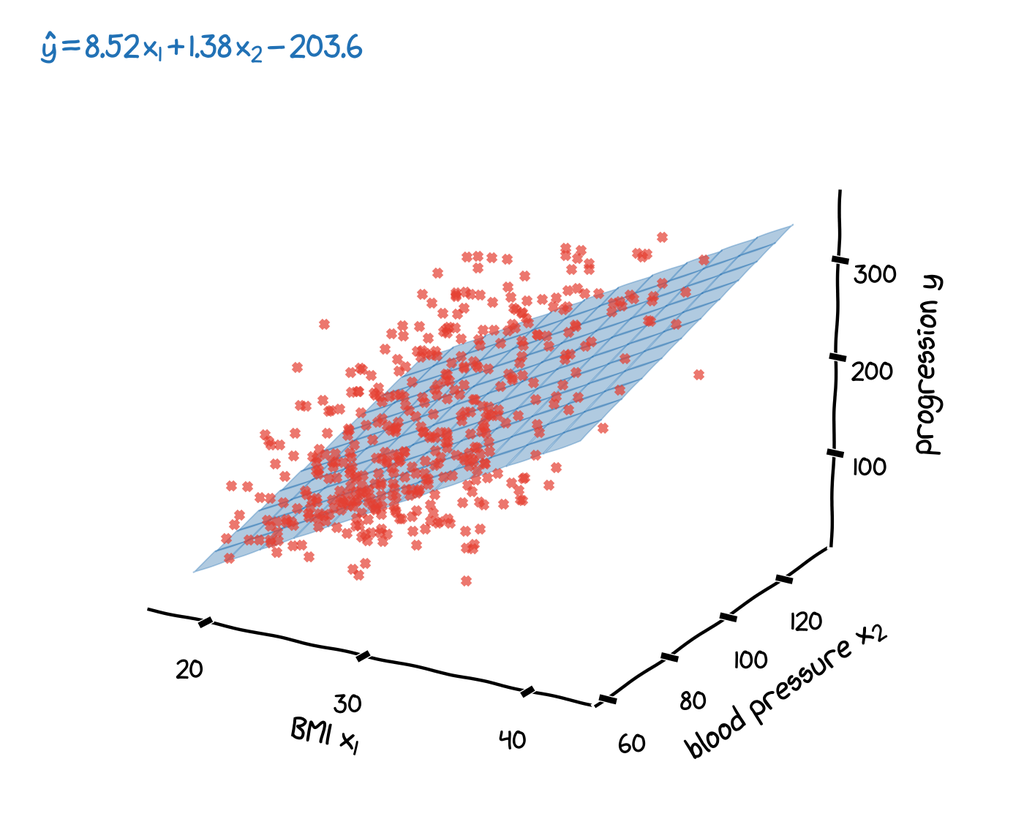

Fitting BMI $x_1$ and blood pressure $x_2$ together gives
$$\hat y = 8.52\,x_1 + 1.38\,x_2 - 203.6 .$$

- One more unit of BMI, at the **same** blood pressure: about $8.5$ points more progression.
- With BMI alone (part 2a) the slope was $10.23$. Patients with a high BMI also tend to have a high blood pressure, so part of that effect is now explained by $x_2$.
- With $n$ features the model is a (hyper)plane in $n+1$ dimensions; we can no longer draw it, but the algebra is the same.